# サンドイッチ構造と設計

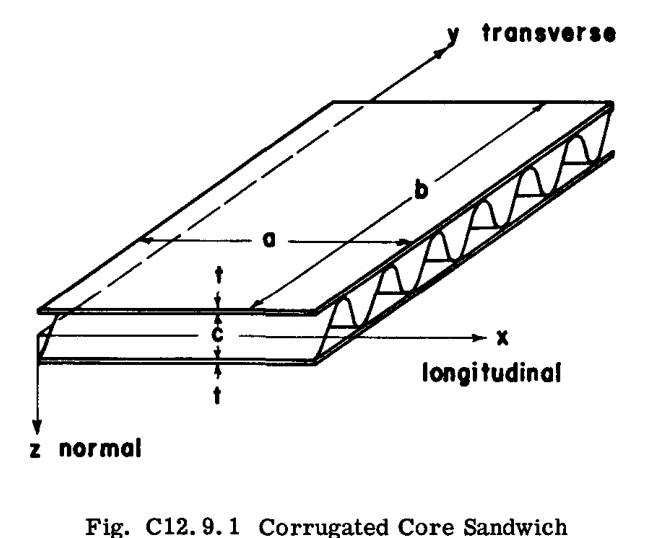

Corrugated Core Sandwich

$$\text{Fig. C12.9.1 波板芯サンドイッチ}$$

### 記号一覧

- **a**: $x$ 方向のパネルの長さ
- **b**: $y$ 方向のパネルの長さ
- **c**: 芯材の厚さ
- **D**: サンドイッチ図心軸まわりの面材の曲げ剛性
- **D_c**: 波板の方向における芯材の曲げ剛性
- **U**: 波板に垂直な平面内における芯材のせん断剛性 $U = G'_y c$
- **E**: 面材のヤング率
- **G’_y**: 波板に垂直な平面内における芯材のせん断弾性係数
- **J**: サンドイッチ剛性パラメータ
- **K**: 座屈係数
- **N_{ox}, N_{oy}**: 単位長さあたりの最大圧縮荷重
- **N_x, N_y**: それぞれ $N_{ox}(1 - \alpha_{xy}/b)$ , $N_{oy}(1 - \alpha_{yx}/a)$
- **N_{xy}**: 縁部の単位長さあたりのせん断荷重
- **t**: 各面材の厚さ
- **x, y, z**: 直交座標
- ***: 面材のポアソン比

## C12.9.2 波板サンドイッチパネルの一般座屈係数

安定判定基準を定式化するためにレイリー・リッツのエネルギー法が使用された。座屈形状は二重正弦級数の形式で仮定され、これがエネルギー方程式に代入される。仮定された級数の係数、および全たわみに対する曲げおよびねじれたわみの比に関して、得られた式を最小化することにより、線形同次方程式のシステムが得られ、ここからマトリックス反復法によって座屈係数が評価される。

座屈係数の曲線は Fig. C12.9.2 から Fig. C12.9.10 にプロットされている。本結果の妥当性は、それぞれの軸まわりの面材の曲げ剛性が無視できる場合に限定される。一般に、個々の面材の曲げ剛性は、パラメータ $G_{cb}$ が小さくなるにつれてますます重要になる。結果の精度も $J$ が減少するにつれて低下する。

提示されているすべての曲線は、 $D_c/D = 0$ および $\mu = 0.3$ に対するものである。 $D_c/D$ 比が $0$ から $0.4$ まで変化した場合の影響の指標は、軸圧縮およびせん断の場合について Fig. C12.9.11 に示されている。多くの実用的なサンドイッチ構造は、この $D_c/D$ の範囲に収まっており、その範囲では、広い $J$ パラメータの範囲にわたって座屈係数への影響は小さいようである。

ポアソン比 $\mu$ の変化が圧縮およびせん断座屈係数に及ぼす影響は、 $J$ の値が $5.0$ および $0.5$ について調査された。この影響は $J$ の値が増加するにつれて減少し、無限大の $J$ に対応する座屈係数はポアソン比に依存しない。

座屈係数に対する芯材の方向の影響が、圧縮およびせん断について調査された。圧縮の場合、波板が印加荷重と平行である方が座屈係数は大きくなる。さらに、波板が印加荷重と平行である場合、芯材の面積により、与えられた $1 \text{ インチ}$ あたりの荷重に対する印加圧縮応力が減少する。せん断の場合、波板が短い方向に配向している方が座屈係数は大きくなる。これらの結論は、補強板の挙動と一致している。

Seide（文献 12）は、芯材が縦方向にある縦圧縮下での、単純支持された波板芯サンドイッチの座屈係数の曲線を提示している。Seide によって図示された結果と、本節で提示された結果との間で比較が行われ、2つの解析によって得られた結果の間に良好な一致が存在することが示された。

座屈係数曲線は、いくつかの重要な荷重条件について提示されている。多くの実用的なサンドイッチ構成において、ポアソン比および芯材の縦曲げ剛性が座屈係数に及ぼす影響は、芯材のせん断剛性の影響と比較して比較的小さいようである。

全体的な不安定性に加えて、サンドイッチ板は、提示された曲線では考慮されていない局所的な破壊モードについて解析されなければならない。

## 軸圧縮 (Axial Compression)

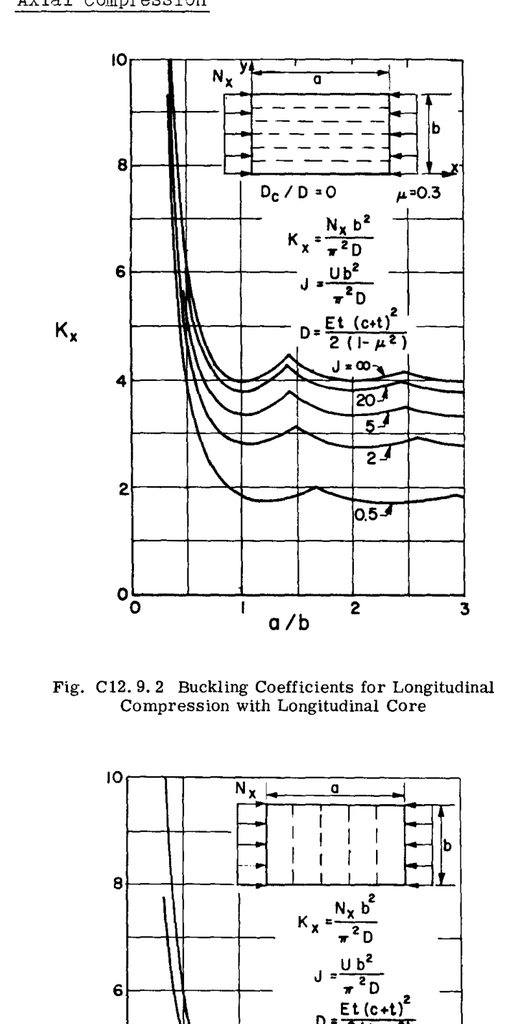

Fig. C12.9.2

$$\text{Fig. C12.9.2 縦方向芯材を持つ縦圧縮の座屈係数}$$

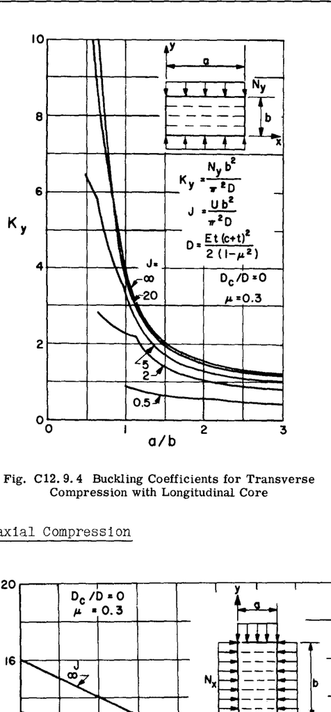

Fig. C12.9.4

$$\text{Fig. C12.9.4 縦方向芯材を持つ横圧縮の座屈係数}$$

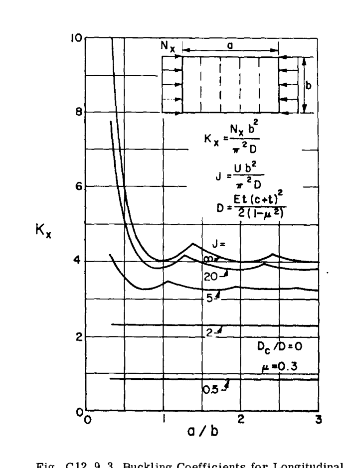

Fig. C12.9.3

$$\text{Fig. C12.9.3 横方向芯材を持つ縦圧縮の座屈係数}$$

## 二軸圧縮 (Biaxial Compression)

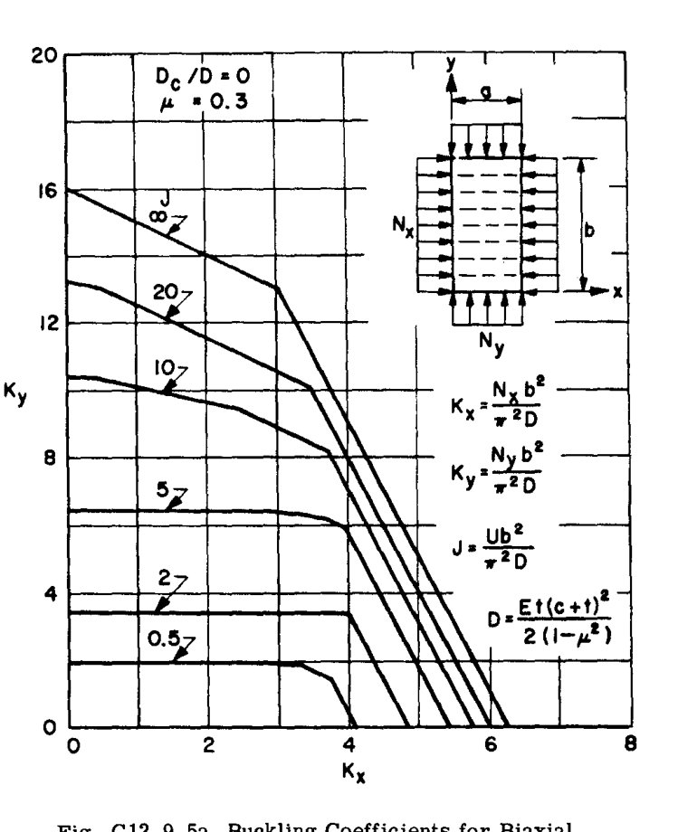

Fig. C12.9.5a

$$\text{Fig. C12.9.5a 二軸圧縮の座屈係数; } a/b = 1/2$$

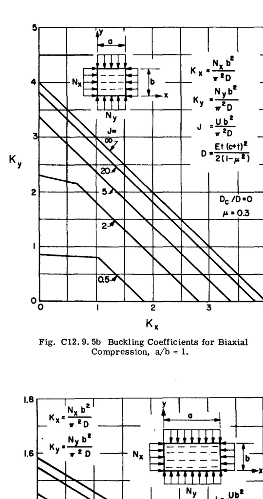

Fig. C12.9.5b

$$\text{Fig. C12.9.5b 二軸圧縮の座屈係数; } a/b = 1$$

## せん断 (Shear)

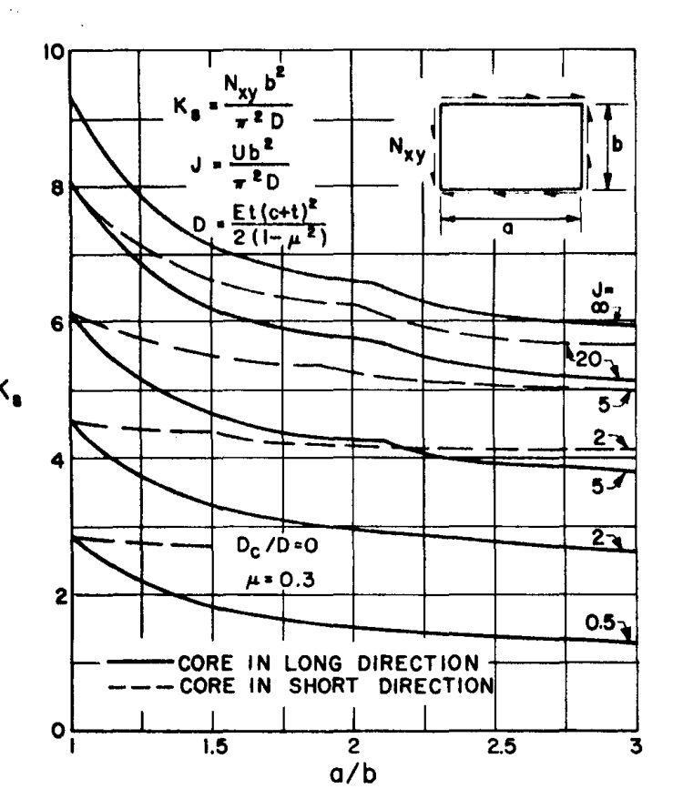

Fig. C12.9.6

$$\text{Fig. C12.9.6 縦方向および横方向芯材を持つせん断の座屈係数}$$

[figure not shown]

Fig. C12.9.5c

$$\text{Fig. C12.9.5c 二軸圧縮の座屈係数; } a/b = 2$$

## 軸圧縮およびせん断 (Axial Compression and Shear)

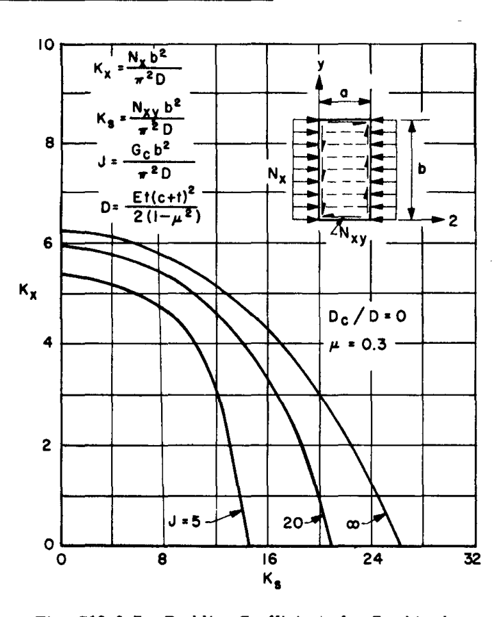

Fig. C12.9.7a

$$\text{Fig. C12.9.7a 縦方向芯材を持つ縦圧縮とせん断の結合座屈係数; } a/b
= 1/2$$

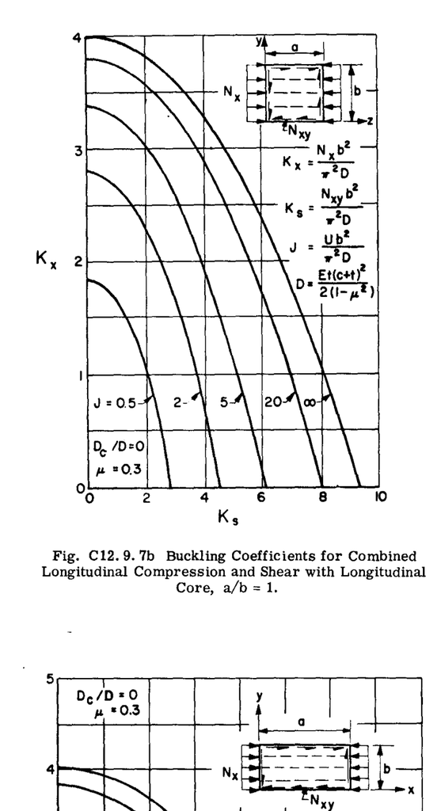

Fig. C12.9.7b

$$\text{Fig. C12.9.7b 縦方向芯材を持つ縦圧縮とせん断の結合座屈係数; } a/b
= 1$$

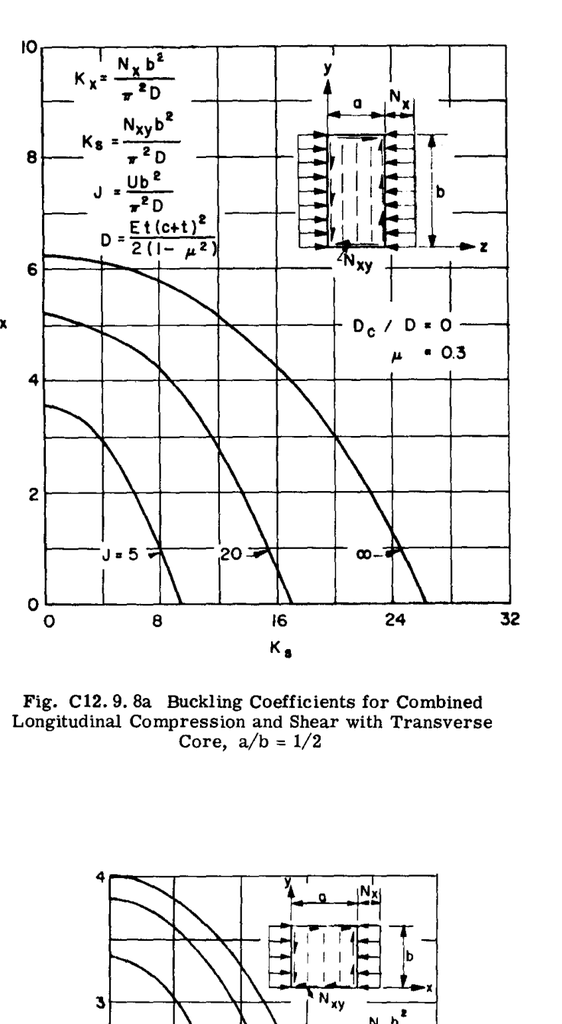

Fig. C12.9.8a

$$\text{Fig. C12.9.8a 横方向芯材を持つ縦圧縮とせん断の結合座屈係数; } a/b
= 1/2$$

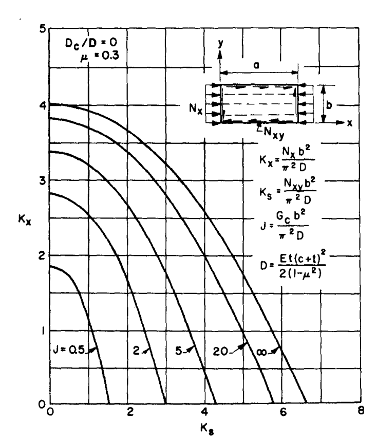

Fig. C12.9.7c

$$\text{Fig. C12.9.7c 縦方向芯材を持つ縦圧縮とせん断の結合座屈係数; } a/b
= 2$$

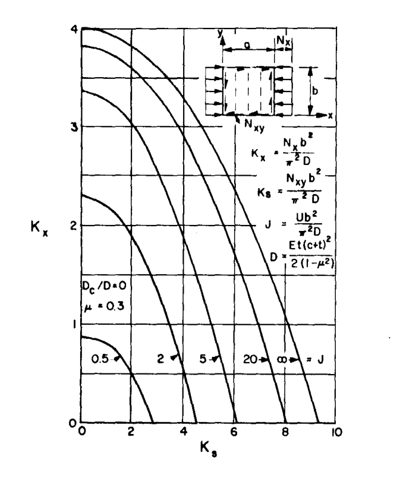

Fig. C12.9.8b

$$\text{Fig. C12.9.8b 横方向芯材を持つ縦圧縮とせん断の結合座屈係数; } a/b
= 1$$

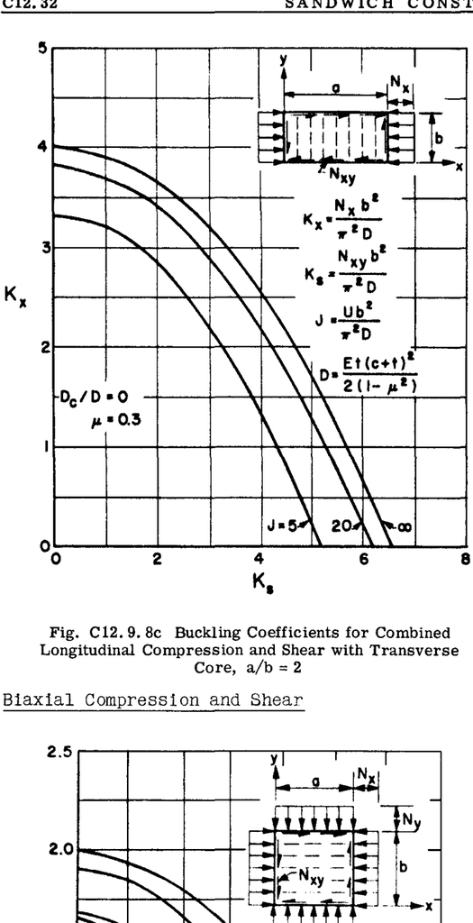

Fig. C12.9.8c

$$\text{Fig. C12.9.8c 横方向芯材を持つ縦圧縮とせん断の結合座屈係数; } a/b
= 2$$

## 曲げ (Bending)

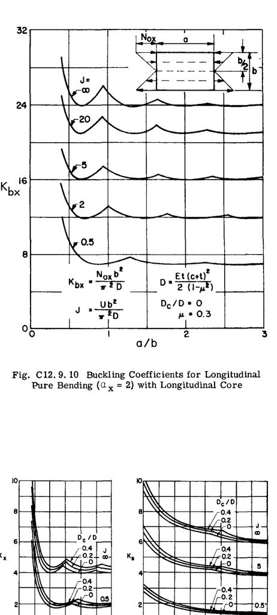

Fig. C12.9.10

$$\text{Fig. C12.9.10 縦方向芯材を持つ縦方向純曲げ (}\alpha_x = 2\text{)
の座屈係数}$$

## 二軸圧縮およびせん断 (Biaxial Compression and Shear)

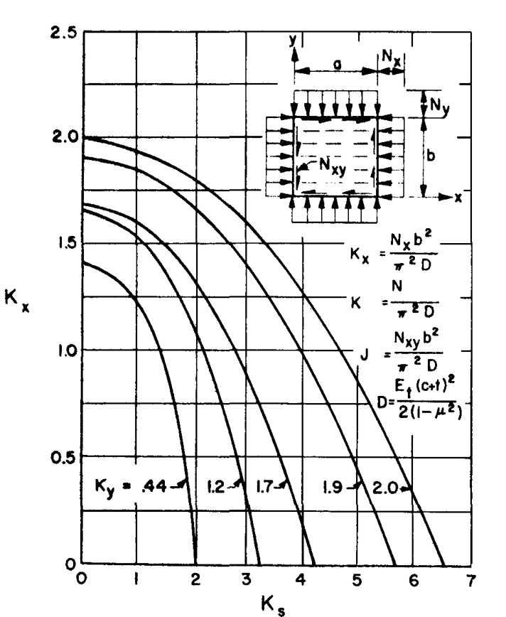

Fig. C12.9.9

$$\text{Fig. C12.9.9
縦方向芯材を持つ縦圧縮、横圧縮、およびせん断の結合座屈係数}$$

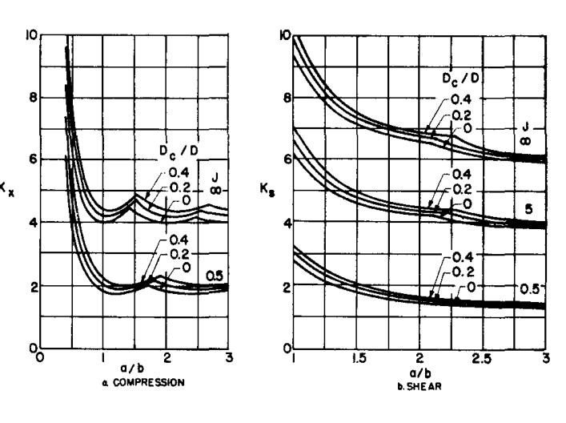

Fig. C12.9.11

$$\text{Fig. C12.9.11 縦方向芯材を持つ圧縮およびせん断の座屈係数に対する }
D_c/D \text{ 比の影響}$$

以下の例は、波板サンドイッチパネルの許容弾性荷重を求める際の座屈係数曲線の適用方法を示している。

**与えられた条件**: - **材料**: 2024-T4 アルミニウム - $E = 10 \times 10^6 \text{ psi}$ - $G'_y = 50,000 \text{ psi}$ - $F_{cy} = 40,000 \text{ psi}$ - **形状**: - $c = 0.5 \text{ in.}$ - $t = 0.05 \text{ in.}$ - $b = 20 \text{ in.}$ - $a = 20 \text{ in.}$

縦方向軸圧縮に対する許容荷重を計算する。

$$U = G'_y c = 50000 \times 0.5 = 25000 \quad \text{REF(10)}$$

$$D = \frac{10 \times 10^6 \times 0.05 (0.5 + 0.05)^2}{2 (1 - 0.09)} =
83000$$

$$J = \frac{25000 (20)^2}{\pi^2 83000} = 12.1$$

$$K_x = 3.6 \quad \text{Ref. Fig. C12.9.2}$$

$$\text{許容 } N_x = \frac{K_x \pi^2 D}{b^2} = \frac{3.6 \times \pi^2
\times 83000}{(20)^2} = 7370 \text{ lb./in.}$$

二軸圧縮に対する許容荷重を計算する。

印加された終局 $N_x = 5000 \text{ lb./in.}$

- $U = 25000$
- $J = 12.1$
- $D = 83000$

$$K_x = \frac{5000 (20)^2}{\pi^2 83000} = 2.45$$

$$K_y = 1.35 \quad \text{Ref. Fig. C12.9.5b}$$

## C12.10 サンドイッチ構造の設計

### C12.10.1 概要

現代の航空機における性能要件の向上に伴い、最小重量設計がますます強調されている。現在の技術水準では、最小重量設計を達成するために、多くの領域でハニカム型の構造を使用することが求められている。可能な効率性を活かすために、ハニカムパネルの設計には細心の注意を払わなければならない。設計者が許容方程式から各パネルの設計を開始することを要求される場合、この問題の大きさは許容可能な設計時間を超えてしまう。ハニカムパネルの断面を記述するための5つのパラメータ（ $t_{F_1}$ , $t_{F_2}$ , $h$ , $t_c/s$ , $s$ ）、パネルの構成を記述するための2つのパラメータ（ $b$ , $a/b$ ）、およびパネルの荷重を記述するための6つのパラメータ（ $P_x$ , $P_y$ , $Q$ , $V$ , $M_x$ , $M_y$ ）が存在するため、ハニカム設計の最適化問題は非常に骨の折れるものになる可能性がある。

本節では、サンドイッチ構造の設計のために、セクション C12.4 から C12.9 で提示された許容方程式の使用方法を示す。セクション C12.2 および Fig. C12.2.1 を参照すると、最も単純なハニカムパネル設計であっても、主要な破壊モードの許容方程式のそれぞれを考慮しなければならない。サンドイッチ構造の効率的な設計のための一般的な規則として、各破壊モードの臨界応力は、印加される終局応力と等しくあるべきであると確立できる。しかし、この規則に従うことだけでは、最も効率的なサンドイッチ構造を保証することはできない。多くの構造において、許容応力レベルが高ければ高いほど、構造はより効率的になる。これはサンドイッチ構造には必ずしも当てはまらない。サンドイッチ面材の応力レベルが高くなれば、それだけ多くの芯材が必要になることを覚えておかなければならない。真の最適化が行われれば、最適な応力レベルは印加荷重レベルの関数であることを示すことができる。本節では、設計者が多くの可能な許容方程式を通じて多数のパラメータを操作する必要性を排除するデータも提示する。このデータは、与えられた条件に対して最も効率的なパネルを設計者に示す。このような一般的なデータに到達するために使用される方法は、それぞれの許容値の観点から重量方程式を書くことである。次に、この重量方程式は、変数のパラメータの関数として最小重量を生成するために、いくつかの方法のいずれかによって最小化される。ほとんどの場合、派生した最小重量方程式から最適なパネル構成を計算するためにデジタルコンピュータを使用しなければならない。この反復プロセスで生成されたデータは、最適な設計を直接選択できる形式でデータを提示する。

### C12.10.2 サンドイッチ面材のディンプリング

サンドイッチ構造の芯材が多孔質（ハニカム）または波板材料である場合、面材が芯材の壁の間の空間に座屈またはディンプル（窪み）を生じることがある。面材のディンプリングは、ディンプルの振幅が大きくなり、ディンプルまたは座屈が芯材のセル壁を越えて成長し、面材のしわ（リンクリング）を引き起こさない限り、破壊につながらない可能性がある。もちろん、全構造破壊を引き起こさないディンプリングであっても、荷重を除去した後に永久的なディンプルが残るほど深刻な場合がある。

面材のディンプリングが許容されない場合、設計荷重下でディンプリングが発生しないように、芯材のセルサイズを十分に小さくしなければならない。設計手順は、面材の厚さ（ $t$ ）が既知であり（面材の厚さは設計荷重と選択された面材の圧縮応力を考慮して決定されている）、面材の圧縮応力 $F_c$ および有効圧縮弾性係数 $E_F$ が既知であり、芯材のセルサイズを決定することになっていると仮定する。面材の特性は、使用条件における値とする。すなわち、高温での適用である場合は、高温における面材の特性を設計に使用しなければならない。面材の弾性係数は、面材応力における有効な値とする。この応力が比例限度値を超えている場合は、適切な接線、低減、または修正された圧縮弾性係数を使用しなければならない。

#### 多孔質（ハニカム）芯材を持つサンドイッチ

本節では、サンドイッチ面材がディンプルを起こさないような芯材のセルサイズを決定する手順を説明する。

サンドイッチ面材のディンプリングが発生する面材応力は、実験式 C12.5.1 によって与えられる。

$$F_c = 0.75 E_F (t_F/s)^{3/2}$$

ここで、 $E_F$ は応力 $F_c$ における面材の有効圧縮弾性係数であり、 $t_F$ は面材の厚さ、 $s$ は芯材のセルサイズ（内接円の直径）である。式 C12.5.1 を $s$ について解くと、次式が得られる。

$$s = 0.825 t_F (F_c/E_F)^{-2/3} \quad \cdots (C12.10.1)$$

最大芯材セルサイズは、式 C12.10.1 から決定できる。芯材セルサイズが利用可能なものよりも小さい場合は、同じ縁部荷重でディンプリングが発生するように、より厚い面材とより低い応力を使用する必要がある。式 C12.10.1 は、特定のセルサイズの芯材に対するサンドイッチ面材のディンプリングの面材厚さと応力を求めるためにも使用できる。

せん断下のパネルの面外ディンプリングについても、同様の導出を行うことができる。以下の式が得られる。

$$s = 0.71 t_F (F_s/E_F)^{-2/3} \quad \cdots (C12.10.2)$$

#### 波板芯材を持つサンドイッチ

本節では、サンドイッチ面材または芯材要素が座屈しないように、芯材の波板間の間隔を決定する手順を説明する（文献 13）。芯材軸と平行な方向の縁部圧縮荷重に対して、設計手順は、支持されていない面材または芯材要素の座屈荷重のいずれか低い方に基づいているが、芯材要素が座屈したサンドイッチを利用することも可能かもしれない。芯材軸と垂直な方向の縁部圧縮荷重に対して、設計手順は支持されていない面材要素の座屈荷重に基づいており、芯材は面材要素の端部で回転拘束を引き起こすのに十分に剛であると仮定される。芯材が二重波板である場合、仮定されたように面材要素を座屈させるのに十分な強度を持たない可能性がある。

面材要素または芯材要素の座屈が発生する面材応力は、次式で与えられる。

$$F_c = K E' \left(\frac{t_F}{b_c}\right)^2 \quad \cdots (C12.10.3)$$

ここで、 $E'$ は応力 $F_c$ における面材の有効圧縮弾性係数であり、 $t_F$ は面材の厚さ、 $b_c$ は面材要素の支持されていない幅であり、 $K$ は波板厚さ（ $t_c$ ）と面材厚さ（ $t_F$ ）の比（ $t_c/t_F$ ）、波板要素と面材との間の角度（ $\theta$ ）、および印加される荷重のタイプに依存する係数である。

式 C12.10.3 を $b_c$ について解くと、次式が得られる。

$$b_c = \sqrt{K} t_F \left(\frac{F_c}{E'}\right)^{-1/2} \quad \cdots
(C12.10.4)$$

### C12.10.3 サンドイッチ面材のリンクリング

セクション C12.2 で説明されている面材のリンクリング（しわ）破壊モードは、サンドイッチパネルにおいていかなる程度であっても発生させてはならない。したがって、ここで提示される設計手順は、設計荷重においてそのような破壊を排除する。設計手順は、面材の圧縮応力 $F_c$ と有効圧縮弾性係数 $E_F$ が既知であり、芯材密度パラメータ $t_c/s$ を決定することになっていると仮定する。面材の特性は、使用条件における値とする。

本節では、サンドイッチ面材がリンクリングを起こさない（または芯材から剥がれない）ように、芯材密度パラメータ $t_c/s$ を決定する手順を説明する。サンドイッチ面材のリンクリングが発生する面材応力は、実験式 C12.5.10 によって与えられる。

$$F_c = 0.43 \sqrt[3]{E_F E'_c G'_c}$$

ここで、 $E_F$ は応力 $F_c$ における面材の有効圧縮弾性係数であり、 $E'_c$ は式 C12.4.13 によって与えられる有効芯材圧縮弾性係数であり、 $G'_c$ は式 C12.4.9 または C12.4.10 によって表される有効芯材せん断弾性係数である。 $E'_c$ と $G'_c$ の式を式 C12.5.10 に代入すると、以下の式が得られる。

$$F_c = 0.43 \sqrt[3]{E_F} \cdot 2.13 \left(\frac{2t_c}{s}\right)^{1.415}
E_c \times 2.43 \left(\frac{2t_c}{s}\right)^{1.54} G_c$$

ここで、正方形セル芯材に対して $\left(\frac{\rho'}{\rho}\right) = \frac{2t_c}{s}$ である。

$$F_c = 0.43 \sqrt[3]{E_F} E_c G_c \cdot 5.1
\left(\frac{2t_c}{s}\right)^{2.955} \quad \cdots (C12.10.5)$$

この式を $t_c/s$ について解くと、以下の式が得られる。

$$\frac{t_c}{s} = 0.5 \left[ \frac{1.35 F_c}{(E_F E_c G_c)^{1/3}} \right]
^{1.015} \quad \cdots (C12.10.6)$$

最小芯材密度は、式 C12.10.6 から決定できる。必要な芯材密度が利用可能なものよりも低い場合は、より低い密度を使用するか、面材応力を増加させることができる。芯材密度が得られるものよりも高い場合は、面材応力を減少させるべきである。この同じ方程式は、面内せん断荷重に対する設計にも当てはまる。

### C12.10.4 サンドイッチパネルのせん断クリンピング

セクション C12.2 で説明されているせん断クリンピング破壊モードは、主要な破壊モードの1つとは見なされていないが、あらゆるサンドイッチ設計においてチェックされなければならない。せん断クリンピング許容方程式は、主に芯材密度 $t_c/s$ が既知である場合に芯材の厚さ $c$ を決定するために使用できる。この方程式は、芯材の厚さ $c$ が既知である場合に $t_c/s$ を決定するためにも使用できる。両方のケースにおいて、面材の厚さ $t_F$ と面材応力 $F_c$ が既知であると仮定される。

本節では、サンドイッチパネルがせん断クリンピングで破壊しないように、芯材の厚さと密度パラメータ $t_c/s$ を決定する手順を説明する。サンドイッチパネルのせん断クリンピングが発生する面材応力は、式 C12.5.18 によって与えられる。

$$F_c = \frac{G'_c (c + 2t_F)}{2t_F}$$

この式を $c$ について解くと、次式が得られる。

$$c = \frac{F_c t_F}{1.21 \left(\frac{2t_c}{s}\right)^{1.54} G_c} - 2t_F
\quad \cdots (C12.10.7)$$

この式を $t_c/s$ について解くと、次式が得られる。

$$\frac{t_c}{s} = 0.5 \left[ \frac{F_c t_F}{1.21 G_c (c + 2t_F)} \right]
^{.65} \quad \cdots (C12.10.8)$$

このようにして導出された芯材の厚さは、芯材密度 $t_c/s$ がセクション C12.10.3 で導出されたものと比較されなければならないのと同様に、セクション C12.10.5 の一般座屈方程式から導出された厚さと比較されなければならない。応力または他のパラメータが調整されない限り、最大値を使用しなければならない。

### C12.10.5 サンドイッチパネルの一般座屈

セクション C12.2 で説明されている一般座屈破壊モードは、終局設計荷重の印加によって発生してはならない。設計手順は、面材の圧縮応力 $F_c$ と有効圧縮弾性係数 $E_F$ が既知であり、面材の厚さ $t_F$ と芯材密度パラメータ $t_c/s$ およびパネルサイズ（ $a, b$ ）が既知であり、芯材の厚さ $c$ を決定することになっていると仮定する。材料特性は、使用条件における値とする。

本節では、サンドイッチパネルが全体的な不安定座屈で破壊しないように、芯材の厚さを決定する手順を説明する。サンドイッチパネルの一般座屈が発生する面材応力は、式 C12.5.19 によって与えられる。

$$F_c = \frac{K_c U}{J 2t_F}$$

$$U = G'_c (c + 2t_F)$$

$$J = \frac{b^2 U}{\pi^2 D}$$

$$D = \frac{E t_F (c + t_F)^2}{2(1 - \mu^2)}$$

$$F_c = \frac{\pi^2 K_c E_F (c + t_F)^2}{4b^2 (1 - \mu^2)} \quad \cdots
(C12.10.9)$$

この式を $c$ について解くと、次式が得られる。

$$c = \left[ \frac{4 F_c b^2 (1 - \mu^2)}{\pi^2 K_c E_F} \right]^{1/2} -
t_F \quad \cdots (C12.10.10)$$

パネルサイズ $b$ を除くすべてのパネルパラメータが既知である場合、以下の式を使用して $b$ を決定できる。

$$b = \left[ \frac{\pi^2 K_c E_F (c + t_F)^2}{4 F_c (1 - \mu^2)}
\right]^{1/2} \quad \cdots (C12.10.11)$$

芯材の厚さが、実用的であるよりも厚い場合、または体積要件が許容するよりも厚い場合は、応力レベル $F_c$ またはパネルサイズ $b$ を変更しなければならない。構造用サンドイッチパネルが燃料電池または機器ベイの断熱材として使用されている場合、芯材の厚さ $c$ をより厚くできるのであれば、必要なバックアップ構造を減らすためにパネルサイズ $b$ を大きくすべきである。

他の荷重ケースに対しても同様の導出を行うことができ、結果はそれぞれの荷重条件に対する $K_c$ の変化のみとなる。

### C12.10.5 平板サンドイッチパネルの設計

伝達すべき与えられた荷重と選択された設計応力から設計が始まると仮定すると、面内圧縮荷重下の平らな長方形サンドイッチパネルは、以下の4つの条件に準拠するように設計されなければならない。

1. 面材は、選択された設計圧縮応力に耐えるのに少なくとも十分な厚さであるべきである。
2. 芯材は、設計圧縮荷重下でサンドイッチパネルの全体座屈が発生しないように、十分に厚く、かつ十分に高いせん断弾性係数を持つべきである。
3. 芯材は、いずれの面材のリンクリングも発生しないように、十分に高い弾性係数を持ち、サンドイッチは、十分な面外引張および圧縮強度を持つべきである。（設計手順はセクション C12.10.3 に提示されている。）
4. 芯材がハニカム型であり、面材のディンプリングが許容されない場合、セルサイズは、いずれの面材も芯材のセル内にディンプリングを起こさないように十分に小さくしなければならない。（設計手順はセクション C12.10.2 に提示されている。）

これら4つの条件は満たされなければならない。サンドイッチの全体座屈、あるいは面材のディンプリングやリンクリングは、パネルの全面的な崩壊なしには発生し得ない。理論式を示す詳細な手順は、本節に提示されている。

#### C12.10.5.1 面材厚さとパネルパラメータの決定

圧縮下のハニカムパネルの場合：

$$t_{F_1} F_{c_1} + t_{F_2} F_{c_2} = N \quad \text{（不均等面材の場合）}
\quad \cdots (C12.10.12)$$

$$t_F = \frac{N}{2 F_c} \quad \text{（均等面材の場合）} \quad \cdots
(C12.10.13)$$

ここで、 $t_F$ は面材の厚さ、 $F_c$ は選択された設計面材圧縮応力、 $N$ はパネル縁部の $1 \text{ インチ}$ あたりの設計圧縮荷重であり、 $_1$ , $_2$ は面材 1 および 2 を示す下付き文字である。

異なる材料の面材を持つサンドイッチの面材厚さを決定する際、式 C12.10.12 が満たされなければならないが、いずれの面材の過大応力も避けるために、応力 $F_{c_1}$ と $F_{c_2}$ は $F_{c_1}/E_{s_1} = F_{c_2}/E_{s_2}$ （ここで $E_s$ は面材の正割弾性係数）となるように選択されなければならない。例えば、面材 1 が $F_{cy_1}/E_{s_1} = 0.005$ となるような材料であり、面材 2 が $F_{cy_2}/E_{s_2} = 0.002$ となるような材料である場合、設計は $0.002$ のひずみに基づいていなければならず、そうでない場合、面材 2 は過大応力となる。これを達成するために、面材 1 に対して選択された設計応力を低下させなければならない。

本節では、サンドイッチパネルの全体座屈が発生しないように、芯材の厚さと芯材のせん断弾性係数を決定する手順も説明する。等方性面材を持つサンドイッチパネルの座屈が発生する面材応力は、理論式 C12.5.19 によって与えられ、ここから芯材の厚さ $c$ に対する主要な関係が式 C12.10.10 として導出された。

$$c = \left[ \frac{4 F_c b^2 (1 - \mu^2)}{\pi^2 K_c E_F} \right]^{1/2} -
t_F$$

芯材密度関係（またはせん断弾性係数）は、面材のリンクリング応力方程式 C12.5.10 から導出され、式 C12.10.6 が得られた。

$$\frac{t_c}{s} = 0.5 \left[ \frac{1.35 F_c}{(E_F E_c G_c)^{1/3}} \right]
^{1.015}$$

#### C12.10.5.2 せん断下のハニカムパネルの面材厚さとパネルパラメータの決定

$$t_{F_1} F_{s_1} + t_{F_2} F_{s_2} = N_{xy} \quad
\text{（不均等面材の場合）} \quad \cdots (C12.10.14)$$

$$t_F = \frac{N_{xy}}{2 F_s} \quad \text{（均等面材の場合）} \quad \cdots
(C12.10.15)$$

ここで、 $t_F$ は面材の厚さ、 $F_s$ は選択された設計面材せん断応力、 $N_{xy}$ はパネル縁部の $1 \text{ インチ}$ あたりの設計せん断荷重であり、 $_1$ , $_2$ は面材 1 および 2 を示す下付き文字である。

異なる材料の面材を持つサンドイッチの面材厚さを決定する際、式 C12.10.14 が満たされなければならないが、応力 $F_{s_1}$ と $F_{s_2}$ は $F_{s_1}/G_{s_1} = F_{s_2}/G_{s_2}$ （ここで $G_s$ は面材のせん断弾性係数）となるように選択されなければならない。

芯材のせん断弾性係数は、セクション C12.10.3 で説明した局所破壊基準によって決定でき、式 C12.10.6 と同様の芯材密度 $t_c/s$ の関係を導出する。ただし、式 C12.5.12 を式 C12.5.10 の代わりに使用しなければならず、これは $F_{scr}/\eta^2$ の導出において異なる。

$$\frac{t_c}{s} = 0.5 \left[ \frac{1.35 F_s}{(E_F E_c G_c)^{1/3}}
\right]^{1.015}$$

芯材の厚さ $c$ は、座屈応力方程式 C12.5.20 から導出されなければならず、式 C12.10.10 の導出と同様である。

$$c = \left[ \frac{4 F_s b^2 (1 - \mu^2)}{\pi^2 K_s E_F} \right]^{1/2} -
t_F$$

#### C12.10.5.3 圧縮下の波板パネルの面材厚さとパネルパラメータの決定

$$t_{F_1} F_{c_1} + t_{F_2} F_{c_2} + \frac{t_c F_{cc}}{\cos \theta} = N_x
\quad \text{（不均等面材および芯材厚さの場合）} \quad \cdots (C12.10.16)$$

$$t_F = \frac{N_x}{(2 + \frac{1}{\cos \theta}) F_c} \quad
\text{（均等面材および芯材厚さの場合）} \quad \cdots (C12.10.17)$$

ここで、 $t_F$ は面材の厚さ、 $t_c$ は波板の厚さ、 $F_c$ は選択された設計圧縮応力、 $N_x$ はパネル縁部の $1 \text{ インチ}$ あたりの設計圧縮荷重、 $\theta$ は波板要素と面材との間の角度であり、 $_1$ , $_2$ , $_c$ は面材 1、2、および波板を示す下付き文字である。

異なる材料の面材と波板を持つサンドイッチの厚さを決定する際、式 C12.10.16 が満たされなければならないが、応力 $F_{c_1}$ , $F_{c_2}$ , および $F_{cc}$ は $F_{c_1}/E_{s_1} = F_{c_2}/E_{s_2} = F_{cc}/E_{sc}$ （ここで $E_s$ はそれぞれのサンドイッチ要素の正割弾性係数）となるように選択されなければならない。

芯材の厚さ $c$ は、座屈応力方程式から導出されなければならない。

$$N_x = \frac{K_x \pi^2 D}{b^2}$$

$$D = \frac{E_F t_F (c + t_F)^2}{2(1 - \mu^2)}$$

$$N_x = \frac{K_x \pi^2 E_F t_F (c + t_F)^2}{2 b^2 (1 - \mu^2)}$$

$$c = \left[ \frac{2 N_x b^2 (1 - \mu^2)}{\pi^2 E_F t_F K_x} \right]^{1/2}
- t_F \quad \cdots (C12.10.18)$$

波板の間隔は、式 C12.10.4 によって与えられる。

#### C12.10.5.4 せん断下の波板パネルの面材厚さとパネルパラメータの決定

$$t_{F_1} F_{s_1} + t_{F_2} F_{s_2} + t_c F_{sc} = N_{xy} \quad
\text{（不均等面材および芯材厚さの場合）} \quad \cdots (C12.10.19)$$

$$t_F = \frac{N_{xy}}{2 F_{sF} + F_{sc}} \quad
\text{（均等面材および芯材厚さの場合）} \quad \cdots (C12.10.20)$$

ここで、 $t_F$ は面材の厚さ、 $t_c$ は波板の厚さ、 $F_s$ は選択された設計せん断応力（面材と波板の厚さが等しい場合、等しいせん断ひずみ要件とより長い波板要素のために、 $F_{sc}$ は $F_{sF} \cos \theta$ に等しくなる）、 $N_{xy}$ はパネル縁部の $1 \text{ インチ}$ あたりの設計せん断荷重、 $\theta$ は波板要素と面材との間の角度であり、 $_1$ , $_2$ , $_c$ は面材 1、2、および波板を示す下付き文字である。

芯材の厚さ $c$ は、セクション C12.9 の座屈方程式から導出されなければならない。

$$N_{xy} = \frac{K_s \pi^2 D}{b^2}$$

$$c = \left[ \frac{2 N_{xy} b^2 (1 - \mu^2)}{\pi^2 E_F t_F K_s}
\right]^{1/2} - t_F$$

波板の間隔 $b_c$ は、式 C12.10.4 によって与えられる。

## C12.10.6 サンドイッチ円筒の設計

伝達すべき与えられた荷重と選択された設計応力から設計が始まると仮定すると、軸圧縮荷重下のサンドイッチ構造の壁を持つ円筒は、以下の5つの条件に準拠するように設計されなければならない。

1. 面材は、選択された設計圧縮応力に耐えるのに少なくとも十分な厚さであるべきである。
2. 芯材は、設計圧縮荷重下でサンドイッチ円筒壁の座屈が発生しないように、十分に厚く、かつ十分に高いせん断弾性係数を持つべきである。
3. 芯材は、いずれの面材のリンクリングも発生しないように、十分に高い弾性係数を持ち、サンドイッチは、十分な面外引張および圧縮強度を持つべきである。（設計手順はセクション C12.10.3 に提示されている。）
4. 芯材がハニカム型であり、面材のディンプリングが許容されない場合、セルサイズは、いずれの面材も芯材のセル内にディンプリングを起こさないように十分に小さくしなければならない。（設計手順はセクション C12.10.2 に提示されている。）
5. 円筒全体は、長柱としての座屈が発生しないように、十分な曲げ剛性を持つべきである。

これら5つの条件は満たされなければならない。円筒またはサンドイッチ壁の座屈、あるいは面材のディンプリングやリンクリングは、円筒の全面的な崩壊なしには発生し得ない。面材および芯材の寸法を決定するための詳細な理論式とグラフ、および必要な芯材特性は、以下の段落に提示されている。二重の式が与えられており、1つは異なる材料と厚さの面材を持つサンドイッチ用であり、もう1つは同じ材料と厚さの各面材を持つサンドイッチ用である。面材の弾性係数 $E_F$ および応力値 $F_c$ は、使用条件における圧縮値とする。すなわち、応用が高温である場合は、高温における面材特性を設計に使用しなければならない。面材の弾性係数は、面材応力における有効な値とする。この応力が比例限度値を超えている場合は、適切な接線、低減、または修正された圧縮弾性係数を使用しなければならない。

### C12.10.6.1 軸圧縮下の円筒の面材厚さとパネルパラメータの決定

$$t_{F_1} F_{c_1} + t_{F_2} F_{c_2} = N \quad \text{（不均等面材の場合）}
\quad \cdots (C12.10.21)$$

$$t_F = \frac{N}{2 F_c} \quad \text{（均等面材の場合）} \quad \cdots
(C12.10.22)$$

ここで、 $t_F$ は面材の厚さ、 $F_c$ は選択された設計圧縮応力、 $N$ は円筒円周の $1 \text{ インチ}$ あたりの設計圧縮荷重であり、 $_1$ , $_2$ は面材 1 および 2 を示す下付き文字である。

異なる材料の面材を持つサンドイッチの厚さを決定する際、式 C12.10.21 が満たされなければならないが、いずれの面材の過大応力も避けるために、応力 $F_{c_1}$ と $F_{c_2}$ は $F_{c_1}/E_{s_1} = F_{c_2}/E_{s_2}$ （ここで $E_s$ は面材の正割弾性係数）となるように選択されなければならない。例えば、面材 1 が $F_{c_1}/E_{s_1} = 0.005$ となるような材料であり、面材 2 が $F_{c_2}/E_{s_2} = 0.002$ となるような材料である場合、設計は $0.002$ の比に基づいていなければならず、そうでない場合、面材 2 は過大応力となる。これを達成するために、面材 1 に対して選択された設計応力を低下させなければならない。

円筒が細長く、半径が制限されている場合、柱の座屈を防ぐために面材の厚さを増加させなければならない場合がある。

本節では、サンドイッチ円筒壁の全体座屈が発生しないように、芯材の厚さと芯材のせん断弾性係数を決定する手順も説明する。手順は、長い円筒の壁に形成されるような、1つの理想的な座屈の長さよりも長い円筒に適用可能である。一般に、理想的な座屈の長さは、芯材のせん断弾性係数が高い場合、円筒の半径にほぼ等しい。芯材のせん断弾性係数が減少するにつれて、それは半径よりも短くなる。理想的な座屈の長さよりも短い円筒の場合、壁の座屈が発生する荷重は、ここに提示されているものよりも高くなる。

サンドイッチ壁の座屈が発生する面材応力は、理論式 C12.6.5 によって与えられる。

芯材のせん断弾性係数は、式 C12.10.6 によって与えられる芯材密度 $t_c/s$ の関係を導出することにより、セクション C12.10.3 で説明した局所破壊基準によって決定できる。

$$\frac{t_c}{s} = 0.5 \left[ \frac{1.35 F_c}{(E_F E_c G_c)^{1/3}}
\right]^{1.015}$$

芯材の厚さまたは厚さ $c$ は、以下のように座屈応力方程式 C12.6.5 から導出されなければならない。

$$\frac{F_{xcr}}{\eta} = \frac{K_x}{J_c} \frac{U}{2t_F}$$

$$K_x = \frac{(m^2 + n^2 \beta_1^2)^2}{m^2 \left[ 1 + \frac{m^2 + n^2
\beta_1^2}{J_c} \right]} + \frac{.0374 m^2 \left[ \frac{L^2}{R(c + t_F)}
\right]^2}{(m^2 + n^2 \beta_1^2)^2}$$

$$J_c = \frac{L^2 U}{\pi^2 D} \quad U = G'_c (c + 2t_F)$$

$$D = \frac{E_F t_F (c + t_F)^2}{2(1 - \mu^2)} \quad \beta_1 = L/2\pi R$$

$$\frac{F_{xcr}}{\eta} = \left[ \frac{(m^2 + n^2 \beta_1^2)^2}{m^2 \left[
1 + \frac{m^2 + n^2 \beta_1^2}{J_c} \right]} + \frac{.0374 m^2 \left[
\frac{L^2}{R(c + t_F)} \right]^2}{(m^2 + n^2 \beta_1^2)^2} \right]
\frac{\pi^2 E_F (c + t_F)^2}{L^2 4(1 - \mu^2)}$$

$$\frac{F_{xcr}}{\eta} = \left[ \frac{(m^2 + n^2 \beta_1^2)^2}{m^2 \left[
1 + \frac{\pi^2 E_F t_F (c + t_F)^2 (m^2 + n^2 \beta_1^2)}{2 L^2
G'_c (c + 2t_F)(1 - \mu^2)} \right]} \right] \frac{.0374 L^2
m^2}{R^2 (c + t_F)^2 (m^2 + n^2 \beta_1^2)^2} \times \frac{\pi^2 E_F (c
+ t_F)^2}{4 L^2 (1 - \mu^2)}$$

$$m^2 + n^2 \beta_1^2 = M$$

$$\frac{F_{xcr}}{\eta} = \left[ \frac{M^2}{m^2 \left[ \frac{1}{(c +
t_F)^2} + \frac{\pi^2 E_F t_F M}{2 L^2 G'_c (c + 2t_F)(1 - \mu^2)}
\right]} + \frac{.0374 L^4 m^2}{R^2 M^2} \right] \frac{\pi^2 E_F}{4 L^2
(1 - \mu^2)}$$

$$m^2 \left[ \frac{F_{xcr}}{\eta} - \frac{.00935 L^2 \pi^2 m^2 E_F}{R^2
M^2 (1 - \mu^2)} \right] = \frac{M^2}{\left[ \frac{4 L^2 (1 -
\mu^2)}{\pi^2 E_F (c + t_F)^2} + \frac{2t_F M}{G'_c (c + 2t_F)}
\right]}$$

$$\text{If} \quad \frac{4 L^2 (1 - \mu^2)}{\pi^2 E_F} = [ \quad ] , \quad
\frac{2t_F M}{G'_c} = \{ \}$$

$$\text{and}$$

$$m^2 \left[ \frac{F_{xcr}}{\eta} - \frac{.00935 L^2 m^2 \pi^2 E_F}{R^2
M^2 (1 - \mu^2)} \right] = ( )$$

$$c^3 ( ) + c^2 \left( 4t_F ( ) - \{ \} \right) + c \left( 5t_F^2 ( ) -
2t_F \{ \} - [ ] \right) + \left( 2t_F^3 ( ) - t_F^2 \{ \} - 2t_F [ ]
\right) = 0 \quad \cdots (C12.10.16)$$

### C12.10.6.2 ねじり下の円筒の面材厚さとパネルパラメータの決定

$$t_{F_1} F_{s_1} + t_{F_2} F_{s_2} = \frac{T}{2A} \quad
\text{（不均等面材、大きな } R/c \text{ に対して近似）} \quad \cdots
(C12.10.23)$$

$$t_F = \frac{T}{4A F_s} \quad \text{（均等面材）} \quad \cdots
(C12.10.24)$$

$$(t_{F_1} F_{s_1} R_1^2 + t_{F_2} F_{s_2} R_2^2) = \frac{T}{2\pi} \quad
\text{（不均等面材、低い } R/c \text{ 比に対して）} \quad \cdots
(C12.10.25)$$

ここで、 $t_F$ は面材の厚さ、 $F_s$ は選択された設計せん断応力、 $T$ は円筒の設計ねじり荷重であり、 $_1$ , $_2$ は面材 1 および 2 を示す下付き文字であり、 $A$ は円筒の閉じた面積、 $R$ は円筒の半径である。

異なる材料の面材を持つ厚さを決定する際、式 C12.10.23 および C12.10.25 が満たされなければならないが、応力 $F_{s_1}$ と $F_{s_2}$ は $F_{s_1}/G_{s_1} R_1 = F_{s_2}/G_{s_2} R_2$ （ここで $G_s$ は面材のせん断弾性係数）となるように選択されなければならない。

芯材のせん断弾性係数は、セクション C12.10.3 で説明した局所破壊基準によって決定でき、セクション C12.10.5.2 と同様の芯材密度 $t_c/s$ の関係を導出する。

$$\frac{t_c}{s} = 0.5 \left[ \frac{1.35 F_s}{(E_F E_c G_c)^{1/3}}
\right]^{1.015}$$

芯材の厚さまたは厚さ $c$ は、式 C12.10.10 の導出と同様に、座屈応力方程式 C12.6.8 から導出されなければならない。

$$c = \left[ \frac{4 F_s L^2 (1 - \mu^2)}{\pi^2 K_s \eta E_F}
\right]^{1/2} - t_F \quad \cdots (C12.10.26)$$

### C12.10.6.3 横圧力下の円筒の面材厚さとパネルパラメータの決定

- **縦応力**:
  $$f_x = \frac{P R}{4 t_F}$$
- **周方向応力**:
  $$f_y = \frac{P R}{2 t_F}$$
- **等しい面材の場合**:
  $$t_F = \frac{P R}{2 F_y} \quad \cdots (C12.10.27)$$
- **不均等面材の場合**:
  $$t_{F_1} F_{y_1} + t_{F_2} F_{y_2} = \frac{P R}{2} \quad \cdots
  (C12.10.28)$$

ここで、 $t_F$ は面材の厚さ、 $F_y$ は $f_x$ が $.5 F_y$ に等しい場合と互換性のある、選択された設計周方向圧縮応力、 $P$ は外部横正圧力、 $R$ は円筒の外半径であり、 $_1$ , $_2$ は面材 1 および 2 を示す下付き文字である。

異なる材料の面材を持つ厚さを決定する際、式 C12.10.28 が満たされなければならないが、応力 $F_{y_1}$ と $F_{y_2}$ は $F_{y_1}/E_{s_1} = F_{y_2}/E_{s_2}$ （ここで $E_s$ は割線弾性係数）となるように選択されなければならない。

芯材のせん断弾性係数は、セクション C12.10.3 で説明した局所破壊基準によって決定でき、式 C12.10.6 と同様の芯材密度 $t_c/s$ の関係を導出する。ただし、式 C12.5.10 の代わりに式 C12.5.13 を使用しなければならない。

ここで、この場合の $\gamma$ は以下の通りである。

$$\gamma = \frac{f_y}{f_x} = 2$$

$$\frac{t_c}{s} = 0.5 \left[ \frac{2.81 F_y}{(E_F E_c G_c)^{1/3}}
\right]^{1.015}$$

芯材の厚さまたは厚さ $c$ は、式 C12.10.16 の導出と同様に、座屈応力方程式 C12.6.10 から導出されなければならない。